# PLUTO: Power Prior Example

Ethan Alt

01/12/2023

### Stan code

Below, we implement the Stan code for the power prior.

```stan
data {
  int<lower=0> ntrt;                 // num. treated patients in current data set
  int<lower=0> nctrl;                // num. placebo patients in current data set
  int<lower=0,upper=ntrt> ytrt;      // num. responders in treated group
  int<lower=0,upper=nctrl> yctrl;    // num. responders in control group
  int<lower=0> J;                    // num. of historical data sets
  array[J] int<lower=0> ntrt0;       // num. treated patients in historical data sets
  array[J] int<lower=0> nctrl0;      // num. placebo patients in historical data sets
  array[J] int<lower=0> ytrt0;       // num. responders in treated group for historical data sets
  array[J] int<lower=0> yctrl0;      // num. responders in placebo group for historical data sets
  array[J] real<lower=0,upper=1> a0; // discounting parameter (could also be vector type)
  real<lower=0> theta_shape1;        // first shape hyperparameter for initial beta prior
  real<lower=0> theta_shape2;        // second shape hyperparameter for initial beta prior
}
parameters {
  real<lower=0,upper=1> theta1;  // probability of responding among treated
  real<lower=0,upper=1> theta0;  // probability of responding among placebo
}
model {
  // power priors
  for ( j in 1:J ) {
    target += a0[j] * binomial_lpmf(ytrt0[j] | ntrt0[j], theta1);    // power prior for treated in j-th data set
    target += a0[j] * binomial_lpmf(yctrl0[j] | nctrl0[j], theta0);  // power prior for placebo in j-th data set
  }
  theta1 ~ beta(theta_shape1, theta_shape2);   // initial prior
  theta0 ~ beta(theta_shape1, theta_shape2);   // initial prior

  // likelihood
  ytrt ~ binomial(ntrt, theta1);
  yctrl ~ binomial(nctrl, theta0);
}
generated quantities {
  real risk_difference = theta1 - theta0;
  real risk_ratio = theta1 * inv(theta0);  // = theta1 / theta0
  real odds_ratio = (theta1 * inv(1-theta1)) / (theta0 * inv(1-theta0));
}
```

In an R session, we would compile the Stan code as follows:

```r
library(cmdstanr)
pp_model <- cmdstan_model('path/to/file/filename.stan')
```

### Setup

First, we load required libraries

```r
library(cmdstanr)
library(posterior)
library(bayesplot)
library(tidyverse)
library(ggthemes)
```

### Analysis in R

#### Creation of the Stan data

Now, we must tell `stan` what the variables named in the `data{}` block are. This is done by creating a named list as follows.

```r
## Create data set
standata <- list(
    'ntrt'   = 53
  , 'nctrl'  = 39
  , 'ytrt'   = 28
  , 'yctrl'  = 17
  , 'J'      = 2
  , 'ntrt0'  = c(273, 290)
  , 'nctrl0' = c(275, 287)
  , 'ytrt0'  = c(118, 167)
  , 'yctrl0' = c(93, 125)
  , 'theta_shape1' = 0.5
  , 'theta_shape2' = 0.5
)
(n <- with(standata, ntrt + nctrl))
```

```
## [1] 92
```

```r
standata$a0 <- c(0.1, 0.1)

## Conduct MCMC sampling
pp_smpl <- pp_model$sample(
  data = standata, iter_warmup = 2000, iter_sampling = 2500
  , chains = 4, parallel_chains = 4, refresh = 0
)
```

```
## Running MCMC with 4 parallel chains...
##
## Chain 1 finished in 0.0 seconds.
## Chain 2 finished in 0.0 seconds.
## Chain 3 finished in 0.0 seconds.
## Chain 4 finished in 0.0 seconds.
##
## All 4 chains finished successfully.
## Mean chain execution time: 0.0 seconds.
## Total execution time: 0.2 seconds.
```

To access the samples, we use the `draws` method, which in turn uses the convenient `posterior` package. We will obtain the draws via a special `data.frame` called a `draws_df`.

```r
pp_mcmc <- pp_smpl$draws(format = 'draws_df')
pp_mcmc %>% summarize_draws()
```

```
## # A tibble: 6 × 10
##   variable     mean  median     sd    mad       q5     q95  rhat ess_b…¹ ess_t…²
##   <chr>       <dbl>   <dbl>  <dbl>  <dbl>    <dbl>   <dbl> <dbl>   <dbl>   <dbl>
## 1 lp__      -68.0   -67.7   1.01   0.706  -7.00e+1 -67.0    1.00   4211.   5927.
## 2 theta1      0.517   0.517 0.0480 0.0486  4.37e-1   0.595  1.00   9289.   6267.
## 3 theta0      0.409   0.409 0.0492 0.0500  3.29e-1   0.491  1.00   8914.   6355.
## 4 risk_dif…   0.108   0.108 0.0683 0.0683 -5.76e-3   0.219  1.00   9557.   6546.
## 5 risk_rat…   1.28    1.26  0.200  0.192   9.88e-1   1.64   1.00   9422.   6838.
## 6 odds_rat…   1.62    1.55  0.467  0.430   9.77e-1   2.46   1.00   9533.   6558.
## # … with abbreviated variable names ¹ess_bulk, ²ess_tail
```

By default, the `summarize_draws()` method gives $90\%$ credible intervals. To obtain a 95% CI, we can do the following:

```r
pp_mcmc %>% summarize_draws(quantile2, .args = list(probs = c(0.025, 0.975)))
```

```
## # A tibble: 6 × 3
##   variable            q2.5   q97.5
##   <chr>              <dbl>   <dbl>
## 1 lp__            -70.7    -67.0
## 2 theta1            0.422    0.609
## 3 theta0            0.313    0.506
## 4 risk_difference  -0.0267   0.241
## 5 risk_ratio        0.945    1.74
## 6 odds_ratio        0.898    2.71
```

More generally, we can summarize different posterior quantities

```r
pp_mcmc %>% summarize_draws(
  'mean', 'sd', ~quantile(.x, probs = c(0.025, 0.975)), 'pgt0' = ~mean(.x > 0), 'pgt1' = ~mean(.x > 1)
)
```

```
## # A tibble: 6 × 7
##   variable           mean     sd   `2.5%` `97.5%`  pgt0  pgt1
##   <chr>             <dbl>  <dbl>    <dbl>   <dbl> <dbl> <dbl>
## 1 lp__            -68.0   1.01   -70.7    -67.0    0     0
## 2 theta1            0.517 0.0480   0.422    0.609  1     0
## 3 theta0            0.409 0.0492   0.313    0.506  1     0
## 4 risk_difference   0.108 0.0683  -0.0267   0.241  0.94  0
## 5 risk_ratio        1.28  0.200    0.945    1.74   1     0.94
## 6 odds_ratio        1.62  0.467    0.898    2.71   1     0.94
```

```r
standata$a0 <- rep(0.2, 2)
pp_smpl2 <- pp_model$sample(
  data = standata, iter_warmup = 2000, iter_sampling = 2500
  , chains = 4, parallel_chains = 4, refresh = 0
)
```

```
## Running MCMC with 4 parallel chains...
##
## Chain 1 finished in 0.0 seconds.
## Chain 2 finished in 0.0 seconds.
## Chain 3 finished in 0.0 seconds.
## Chain 4 finished in 0.0 seconds.
##
## All 4 chains finished successfully.
## Mean chain execution time: 0.0 seconds.
## Total execution time: 0.1 seconds.
```

```r
pp_mcmc2 <- pp_smpl2$draws(format = 'draws_df')
pp_mcmc2 %>% summarize_draws(
  'mean', 'sd', ~quantile(.x, probs = c(0.025, 0.975)), 'pgt0' = ~mean(.x > 0), 'pgt1' = ~mean(.x > 1)
)
```

```
## # A tibble: 6 × 7
##   variable           mean     sd    `2.5%` `97.5%`  pgt0  pgt1
##   <chr>             <dbl>  <dbl>     <dbl>   <dbl> <dbl> <dbl>
## 1 lp__            -70.1   1.01   -72.8     -69.1   0     0
## 2 theta1            0.513 0.0389   0.438     0.590 1     0
## 3 theta0            0.400 0.0399   0.323     0.479 1     0
## 4 risk_difference   0.113 0.0555   0.00430   0.220 0.978 0
## 5 risk_ratio        1.30  0.165    1.01      1.65  1     0.978
## 6 odds_ratio        1.63  0.378    1.02      2.48  1     0.978
```

### Plots

The `bayesplot` package provides nice diagnostic plots.

#### Trace plots

Trace plots show how the MCMC converges. Ideally, we want to see lines randomly fluctuating.

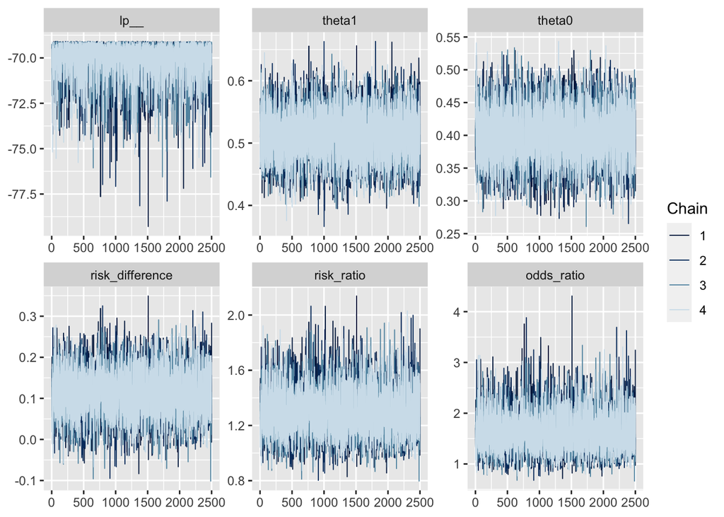

```r
pp_mcmc2 %>% mcmc_trace()
```

#### Autocorrelation plots

Autocorrelation can sometimes be problematic as it can indicate that the chain is “stuck”.

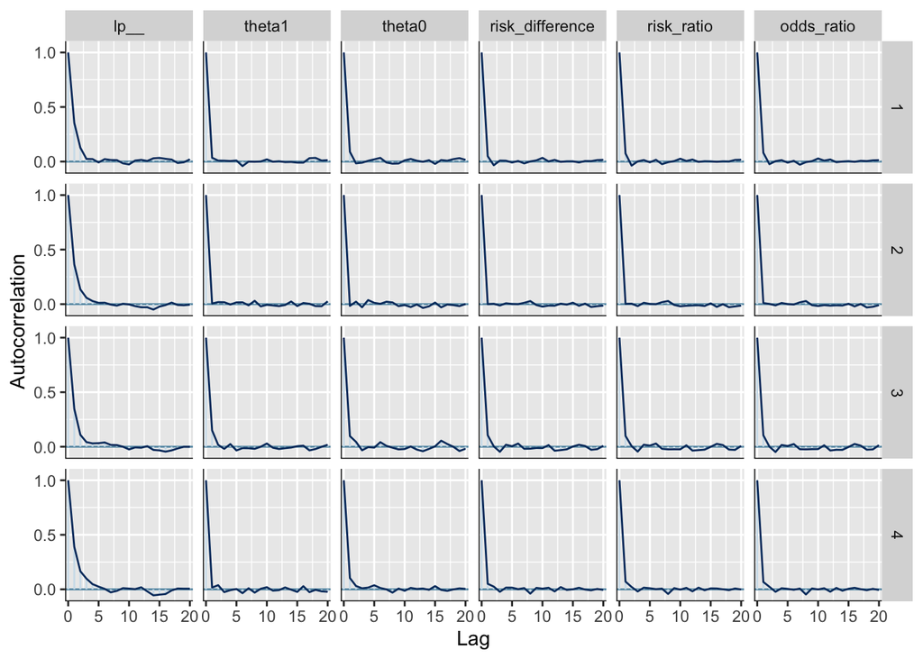

```r
pp_mcmc2 %>% mcmc_acf()
```